# w8a: Moving Average Model

[Nao Mimoto](https://nmimoto.github.io/) - [Dept. of Statistics](http://www.uakron.edu/stat/) : [The University of Akron](http://www.uakron.edu)

[Class Web Page](https://nmimoto.github.io/477/)

## 1. MA(1) Model

First order moving average process is defiend as:
$$X_t \hspace3mm = \hspace3mm
\epsilon_t - \theta_1 \epsilon_{t-1}, \hspace15mm \epsilon_t \sim
WN(0, \sigma^2)$$
and $\theta_1$ is real valued constant.

Compare this to the first order Autoregressive process
$$X_t - \phi_1 X_{t-1}
\hspace3mm = \hspace3mm
\epsilon_t$$

Using the backward operator, MA(1) can be written as
$$X_t \hspace3mm = \hspace3mm
\underbrace{ (1 - \theta_1 B) }_{\Theta(B) } \, \epsilon_t.$$

Watch the sign in front of $\theta_1$! This is Cryer’s convension. See **ARIMA functions** page of the website.

### Mean of MA(1)

$$\begin{align}
E(X_t)
&= \hspace3mm E(\epsilon_t - \theta_1 \epsilon_{t-1}) \\\\
&= \hspace3mm E(\epsilon_t) - \theta_1 E(\epsilon_{t-1})
&= \hspace3mm 0
\end{align}$$

### ACVF at lag 0

$$\begin{align}
\mbox{Var}(X_t)
&= \hspace3mm \mbox{Var}(\epsilon_t - \theta_1 \epsilon_{t-1})\\
\\
&= \hspace3mm \mbox{Var}(\epsilon_t) + \theta_1^2
\mbox{Var}(\epsilon_{t-1})\\ \\
&= \hspace3mm \sigma^2 + \theta_1^2 \sigma^2 \\ \\
&= \hspace3mm (1+\theta_1^2) \sigma^2
\end{align}$$

### ACVF at lag 1

$$\begin{align}
\gamma(1)
&= \hspace3mm \mbox{ Cov }(X_t, X_{t+1} ) \\ \\
&= \hspace3mm
\mbox{ Cov }(\epsilon_t- \theta_1 \epsilon_{t-1}, \hspace3mm
e_{t+1}-\theta_1 e_{t} )\\ \\
&= \hspace3mm \mbox{ Cov }(\epsilon_t , \, e_{t+1} )
- \mbox{ Cov }(\epsilon_t , \, \theta_1 e_{t} )
- \mbox{ Cov }(\theta_1 \epsilon_{t-1}, \, e_{t+1} )
+ \mbox{ Cov }(\theta_1 \epsilon_{t-1}, \, \theta_1 e_{t} ) \\ \\
&= \hspace3mm -\theta_1 \mbox{ Cov }(\epsilon_t , \, e_{t} ) \\
\\
&= \hspace3mm -\theta_1 \, \sigma^2
\end{align}$$

### ACVF at lag 2

$$\begin{align}
\gamma(2)
&= \hspace3mm \mbox{ Cov }(Y_t, Y_{t+2} ) \\ \\
&= \hspace3mm \mbox{ Cov }(\epsilon_t- \theta_1 \epsilon_{t-1},
\hspace3mm e_{t+2}-\theta_1 e_{t+1} )\\ \\
&= \hspace3mm 0
\end{align}$$

### ACVF and ACF of MA(1)

ACVF
$$\gamma(h) =
\left\{
\begin{array}{ll}
\sigma^2(1+\theta_1^2) & \mbox{ if } h=0 \\
-\sigma^2 \theta_1 & \mbox{ if } h= \pm 1 \\
0 & \mbox{ if } |h|>1 \\
\end{array} \right.$$

ACF
$$\rho(h) =
\left\{
\begin{array}{ll}
1 & \mbox{ if } h=0 \\
-\theta_1/ (1+\theta^2_1) & \mbox{ if } h= \pm 1 \\
0 & \mbox{ if } |h|>1 \\
\end{array} \right.$$

## 2. MA(q) Model

Moving Average process of order $q$ is
$$X_t = \epsilon_t - \theta_1 \epsilon_{t-1} - \theta_2 \epsilon_{t-2} -
\cdots - \theta_q e_{t-q},$$
where $\epsilon_t \sim WN(0,\sigma^2)$ and $\theta_1, \ldots, \theta_q$ is real valued constant.

Using the backward operator, we write this as
$$X_t = (1 - \theta_1 B - \theta_2 B^2 - \cdots - \theta_q B^q) \,
\epsilon_t.$$

We shorten the notation further, and write
$$X_t = \Theta(B) Z_t.$$
where **Characteristic Polinomial**, $\Theta(z) = (1 - \theta_1 z - \theta_2 z^2 - \cdots - \theta_q z^q)$.

### Mean and Var of MA(q)

Mean
$$E(X_t)
\hspace3mm = \hspace3mm
E(\epsilon_t - \theta_1 \epsilon_{t-1} - \theta_2 \epsilon_{t-2} -
\cdots - \theta_q e_{t-q})
\hspace3mm = \hspace3mm 0.$$

### ACVF and ACF of MA(q)

$$\begin{align}
\gamma(h)
&= \hspace3mm \mbox{ Cov }(X_t, \hspace3mm X_{t+h} )\\
&= \hspace3mm
\mbox{ Cov }\Big(\epsilon_t - \theta_1 \epsilon_{t-1} - \theta_2
\epsilon_{t-2} - \cdots - \theta_q e_{t-q},
\hspace5mm
e_{t+h} - \theta_1 e_{t-1+h} - \theta_2 e_{t-2+h} - \cdots - \theta_q
e_{t-q+h}\Big)
\end{align}$$

Theoretical ACVF:
$$\gamma(h) =
\left\{
\begin{array}{ll}
\sigma^2 (1+\theta_1^2 \cdots + \theta_q^2) & \mbox{ if } h=0 \\
\sigma^2 (-\theta_1 + \theta_2 \theta_1 + \theta_3 \theta_2 + \cdots +
\theta_{q-1} \theta_{q}) & \mbox{ if } h=1 \\
\sigma^2 (-\theta_2 + \theta_3 \theta_1 + \cdots + \theta_{q-2}
\theta_{q}) & \mbox{ if } h=2 \\
\vdots & \\
\sigma^2 (-\theta_q ) & \mbox{ if } h=q \\
0 & \mbox{ if } |h|>q\\
\end{array} \right.$$

Theoretical ACF:
$$\rho(h) =
\left\{ \begin{array}{ll}
1 & \mbox{ if } h=0 \\
\gamma(h) / \gamma(0) & \mbox{ if } -q \leq h \leq q \\
0 & \mbox{ if } |h|> q \\
\end{array} \right.$$

### Theorem

Every stationary q-corr TS with mean 0 can be represented as MA($q$) process.

## 3. Ex: MA(3)

$$X_t = \epsilon_t - \theta_1 \epsilon_{t-1} - \theta_2 \epsilon_{t-2} -
\theta_3 \epsilon_{t-3}$$

$$\gamma(h) =
\left\{
\begin{array}{ll}
\sigma^2 (1+\theta_1^2 +\theta_2^2 + \theta_3^2 ) & \mbox{ if
} h=0 \\
\sigma^2 (-\theta_1 + \theta_2 \theta_1 + \theta_3 \theta_2 ) &
\mbox{ if } h=1 \\
\sigma^2 (-\theta_2 + \theta_3 \theta_1 ) & \mbox{ if } h=2 \\
\sigma^2 (-\theta_3 ) & \mbox{ if } h=3 \\
0 & \mbox{ if } |h|> \\
\end{array} \right.$$

$$\rho(h) = \gamma(h) / \gamma(0)$$

Watch the Sign!

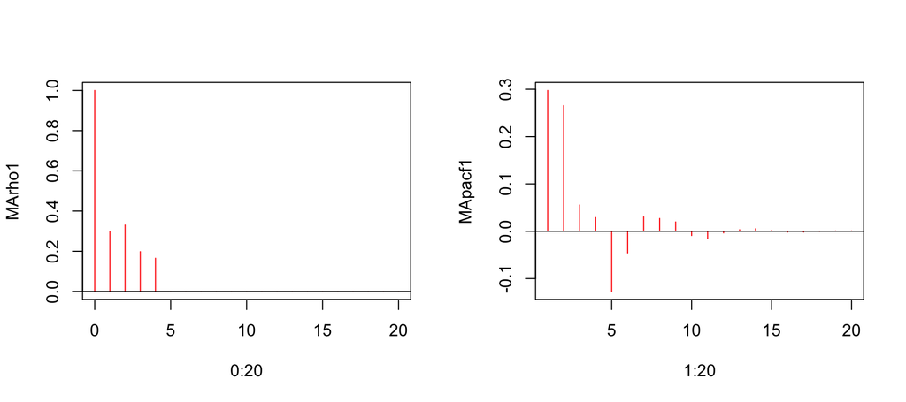

```r
#   [Cryer]'s sign convention is (1-phi B) Y_t = (1-theta) \epsilon_t.
#   [Brockwell]'s             is (1-phi B) Y_t = (1+theta) \epsilon_t.
#
#   For AR(1) (1-.5 B) Y_t = \epsilon_t,          ACF should be all positive.
#             (1+.5 B) Y_t = \epsilon_t,          ACF should be alternating in sign.
#
#   For MA(1)          Y_t = (1-.5 B) \epsilon_t  ACF at lag 1 should be negative
#                      Y_t = (1+.5 B) \epsilon_t  ACF at lag 1 should be positive

#--- Theoretical ACF and PACF of MA ---
#     ARMAacf() uses  sign of MA parameters like [Brockwell]:  Y_t = (1+theta B) \epsilon_t
    Theta = c(.2,  .3, .2,  .2)

    MArho1 = ARMAacf(ma = Theta, lag.max=20, pacf=FALSE)
    MApacf1<- ARMAacf(ma = Theta, lag.max=20, pacf=TRUE)

    layout(matrix(1:2, 1,2))
    plot(0:20, MArho1, type="h", col="red");   abline(h=0)
    plot(1:20, MApacf1, type="h", col="red");   abline(h=0)
```

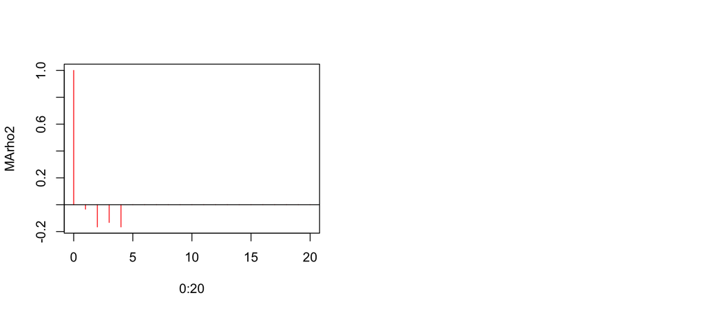

```r
#--- Theoretical ACVF of MA
#
#   tacvfARMA() uses sign of MA parameters like [Cryer]:  Y_t = (1 - theta B) \epsilon_t
#

  library(ltsa)

  MAgam2 = tacvfARMA(theta= c(.2, .3, .2, .2), maxLag=20, sigma2=1)  #- Theoretical ACVF
  MArho2 = MAgam2/MAgam2[1]                                          #- Theoretical ACF

  plot(0:20, MArho2, type="h", col="red");   abline(h=0)
```